# Inference For Numerical Data

Cameron Smith

10/25/2018

# 1 Bootstrapping for estimating a parameter

## 1.1 Generate bootstrap distribution for median

When building a bootstrap distribution for a single statistic, we first generate a series of bootstrap resamples, and then record the relevant statistic (in this case, the median) of each distribution.

In this exercise, the `tidyverse` packages, including `ggplot2` have been loaded for you, as has `infer`.

```r
manhattan <- read.csv("https://assets.datacamp.com/production/course_5103/datasets/manhattan.csv")
# Generate bootstrap distribution of medians
rent_ci_med <- manhattan %>%
  # Specify the variable of interest
  specify(response = rent) %>%
  # Generate 15000 bootstrap samples
  generate(reps = 15000, type = "bootstrap") %>%
  # Calculate the median of each bootstrap sample
  calculate(stat = "median")

# View the structure of rent_ci_med
str(rent_ci_med)
```

```
## Classes 'tbl_df', 'tbl' and 'data.frame':    15000 obs. of  2 variables:
##  $ replicate: int  1 2 3 4 5 6 7 8 9 10 ...
##  $ stat     : num  2350 2422 2238 2422 2350 ...
##  - attr(*, "response")= symbol rent
##  - attr(*, "response_type")= chr "integer"
##  - attr(*, "distr_param")= Named num 19
##   ..- attr(*, "names")= chr "df"
##  - attr(*, "theory_type")= chr "One sample t"
##  - attr(*, "generate")= logi TRUE
##  - attr(*, "type")= chr "bootstrap"
##  - attr(*, "stat")= chr "median"
```

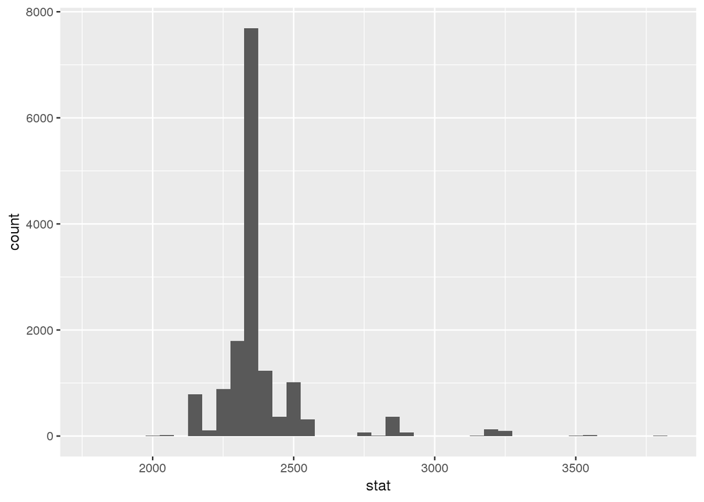

```r
# Plot a histogram of rent_ci_med
ggplot(rent_ci_med, aes(stat)) +
  geom_histogram(binwidth = 50)
```

```r
# Percentile method
rent_ci_med %>%
  summarize(l = quantile(stat, 0.025),
            u = quantile(stat, 0.975))
```

```
## # A tibble: 1 x 2
##       l     u
##   <dbl> <dbl>
## 1 2162.  2875
```

```r
# Standard error method

# Calculate observed median
rent_med_obs <- manhattan %>%
  # Calculate observed median rent
  summarize(median(rent)) %>%
  # Extract numerical value
  pull()

# Determine critical value
t_star <- qt(0.975, df = nrow(manhattan) - 1)

# Construct interval
rent_ci_med %>%
  summarize(boot_se = sd(stat)) %>%
  summarize(l = rent_med_obs - t_star * boot_se,
            u = rent_med_obs + t_star * boot_se)
```

```
## # A tibble: 1 x 2
##       l     u
##   <dbl> <dbl>
## 1 1995. 2705.
```

## 1.2 Which method more appropriate: percentile or SE?

Which method is more appropriate for calculating the bootstrap confidence interval for the median rent of 1 BR apartments in Manhattan?

## 1.3 Doctor visits during pregnancy

The state of North Carolina released to the public a large data set containing information on births recorded in this state. This data set has been of interest to medical researchers who are studying the relation between habits and practices of expectant mothers and the birth of their children. The `ncbirths` dataset (which is already loaded for you) is a random sample of 1,000 cases from this data set. Among other variables, the number of doctor’s visits (`visits`) the mother had throughout the pregnancy is recorded. Which of the following is false about the distribution of `visits`?

*`The number of doctor's visits for one of the mothers in the dataset is missing.`